#### Question2(e)

#### Forecasting 2 years GDP values

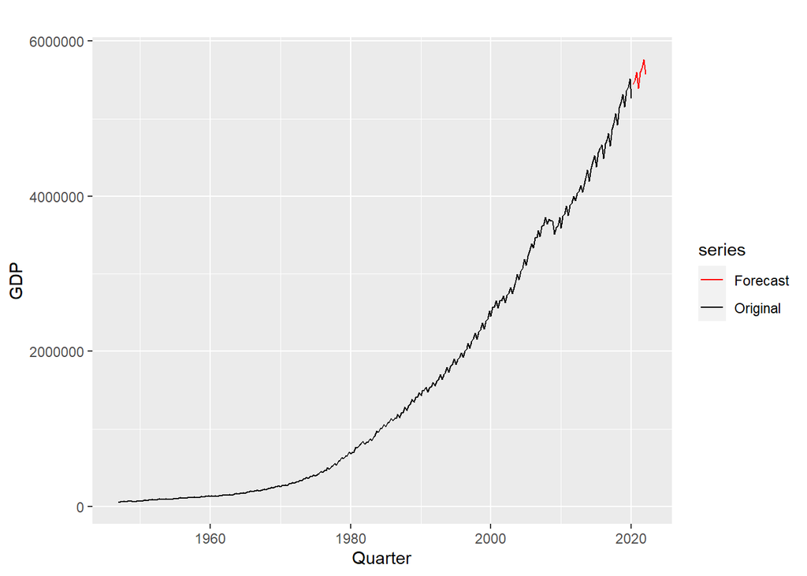

```r
forecast2e <- forecast(model2c3, h = 8)
focast <- InvBoxCox(forecast2e$mean, BoxCox.lambda(gdpts))
options("scipen"=100, "digits"=4)
autoplot(gdpts, series = 'Original') + xlab('Quarter') + ylab('GDP') +
  autolayer(focast, series = 'Forecast') +
  scale_colour_manual(values=c('Original' = 'black', 'Forecast' = 'red'))
```

#### Question2(f)

#### Running ETS model and comparing it to best ARIMA model

```r
model2f <- ets(gdpts)
ets2f <- summary(model2f)
```

```
## ETS(M,A,M)
##
## Call:
##  ets(y = gdpts)
##
##   Smoothing parameters:
##     alpha = 0.8138
##     beta  = 0.1912
##     gamma = 0.1862
##
##   Initial states:
##     l = 60240.9521
##     b = 1294.1479
##     s = 1.057 0.9931 0.9778 0.9723
##
##   sigma:  0.0132
##
##  AIC AICc  BIC
## 7045 7046 7078
##
## Training set error measures:
##                 ME  RMSE   MAE     MPE   MAPE   MASE   ACF1
## Training set 638.4 17998 10265 0.09831 0.9362 0.1347 0.1673
```

```r
accuracy(model2f)
```

```
##                 ME  RMSE   MAE     MPE   MAPE   MASE   ACF1
## Training set 638.4 17998 10265 0.09831 0.9362 0.1347 0.1673
```

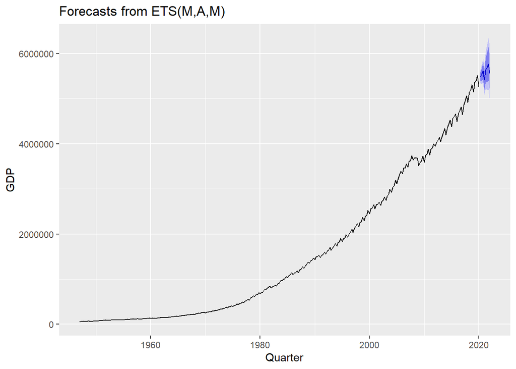

```r
aic2f <- model2f$aic
RMSE2f <- ets2f[2]

focast2 <- forecast(model2f, h=8)

autoplot(focast2) +
  xlab("Quarter") +
  ylab("GDP")
```

```r
modelfaa <- auto.arima(gdpts)
sumfaa <- summary(modelfaa)
```

```
## Series: gdpts
## ARIMA(3,1,1)(0,1,2)[4]
##
## Coefficients:
##         ar1    ar2     ar3     ma1    sma1    sma2
##       1.077  0.035  -0.264  -0.928  -0.265  -0.132
## s.e.  0.068  0.093   0.061   0.035   0.070   0.053
##
## sigma^2 estimated as 307035446:  log likelihood=-3221
## AIC=6455   AICc=6456   BIC=6481
##
## Training set error measures:
##                ME  RMSE  MAE    MPE   MAPE   MASE     ACF1
## Training set 1882 17190 9879 0.2229 0.9072 0.1296 -0.01849
```

```r
aicfaa <- modelfaa$aic
RMSEfaa <- sumfaa[2]

options(scipen=999)
tab2f<- matrix(c( RMSEfaa,  RMSE2f, aicfaa, aic2f), ncol=2, byrow=T)
colnames(tab2f) = c("Auto Arima","ETS")
rownames(tab2f) <- c("RMSE", "AIC")
tab2f
```

```
##      Auto Arima   ETS
## RMSE      17190 17998
## AIC        6455  7045
```

As shown above that the RMSE for auto-arima is 17190 which is lesser than that from ets model at 17998, we can conclude that the Auto-Arima model (3,1,1)(0,1,2)[4] is a better performing model among the two.

#### Question3(a)

##### a.Set up the data set for analysis. If necessary, find a suitable Box-Cox transformation for the data set (see Hyndman, section 3.2).

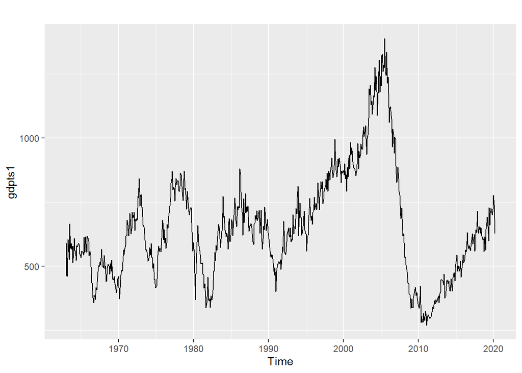

```r
data2 <- read.csv('hw6_one_family_homes.csv')
gdpts1 <- ts(data2[,2], start = 1963, frequency = 12)
autoplot(gdpts1)
```

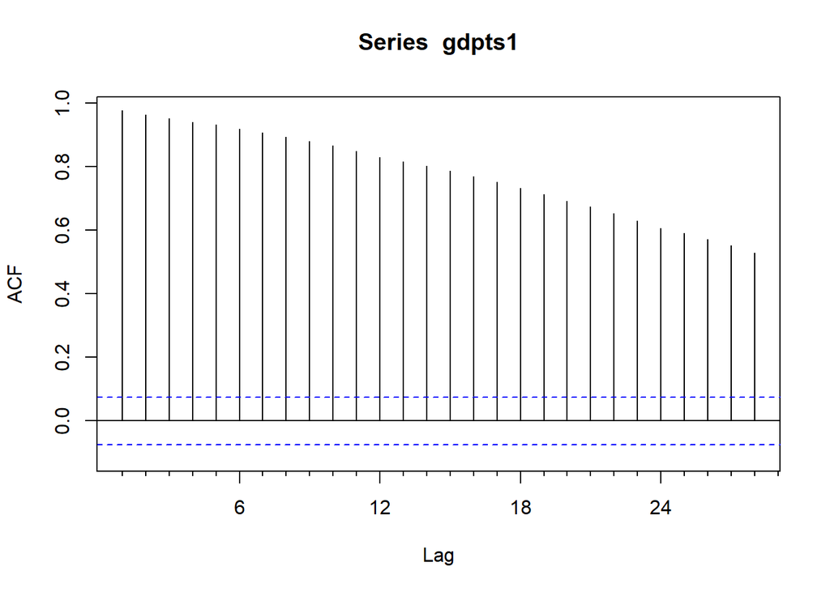

```r
Acf(gdpts1)
```

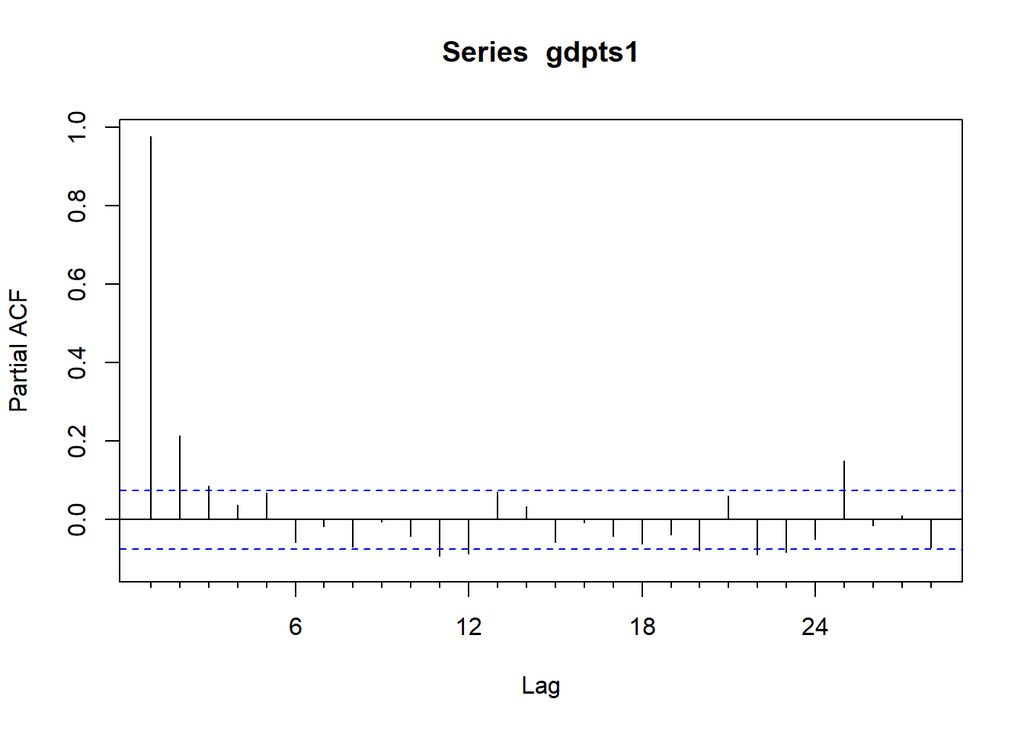

```r
Pacf(gdpts1)
```

```r
Box.test(gdpts1, lag = 1)
```

```
##
##  Box-Pierce test
##
## data:  gdpts1
## X-squared = 654, df = 1, p-value <0.0000000000000002
```

```r
# Data is correlated in time due to low p-value, so null hypothesis is rejected
Box.test(gdpts1, lag = 12)
```

```
##
##  Box-Pierce test
##
## data:  gdpts1
## X-squared = 6818, df = 12, p-value <0.0000000000000002
```

```r
lambda <- BoxCox.lambda(gdpts1)
lambda
```

```
## [1] 0.593
```

After setting up the data we can notice that the lambda is quite high 0.593 so there is no need to transform the data in this case. We will use the un-transformed data for all further analysis.